# Final_project

**Задачи проекта**

1. Выбрать набор данных.Распределение наборов данных по группам должно быть равномерным. Название набора даных скопировать в таблицу с срапределениями по командам, поставить + напротив соответствующей строки таблицы «Наборы данных»
2. Изучить набор данных, исследовать на пропуске, выбросы, балансировку по классам и тд
3. Для решения задачи выбрать 3 модели. Минимум одна модель – классическое машинное обучение. Минимум одна модель – глубокий/нейросетевой подход.
4. Выбрать функцию потерь.
5. Выбрать критерии качества решения задачи.
6. Произвести тренировку моделей. Выбрать наилучший.
7. Подготовить презентацию с постановкой задачи, описание наборов данных, моделей, результатами исследований.

**Информация про набор данных**

набор данных: Web Traffic Time Series Forecasting  
Ссылка на набор данных: https://www.kaggle.com/datasets/ymlai87416/wiktraffictimeseriesforecast/data

**Содержание набора данных:**  
Медиана 7-49 дней  
Медиана с выходными 7-49 дней  
ежедневно с праздниками  
ежедневно с праздниками и журналом  
ежегодно с праздниками и журналом

```python
import pandas as pd

file_path = 'validation_score.csv'
df = pd.read_csv(file_path)
print(df)
```

```
        Unnamed: 0   median7  median14  median21  median28  median35  \
0                0  0.394786  0.398010  0.405826  0.405826  0.405826
1                1  0.415525  0.436615  0.484943  0.542946  0.484943
2                2  0.688429  0.500956  0.500956  0.492091  0.492091
3                3  0.356799  0.347737  0.356799  0.347737  0.356799
4                4  0.443860  0.453087  0.442593  0.489076  0.586340
...            ...       ...       ...       ...       ...       ...
145058      145058  0.200000  0.200000  0.200000  0.200000  0.200000
145059      145059  0.000000  0.000000  0.000000  0.000000  0.000000
145060      145060  0.000000  0.000000  0.000000  0.000000  0.000000
145061      145061  0.000000  0.000000  0.000000  0.000000  0.000000
145062      145062  0.000000  0.000000  0.000000  0.000000  0.000000

        median42  median49  median7_h  median14_h  median21_h  median28_h  \
0       0.405826  0.405826   0.489267    0.415286    0.405018    0.403895
```

[output cut: 25 more lines]

```
Общая информация о наборе данных:
<class 'pandas.core.frame.DataFrame'>
RangeIndex: 145063 entries, 0 to 145062
Data columns (total 18 columns):
 #   Column       Non-Null Count   Dtype
---  ------       --------------   -----
 0   Unnamed: 0   145063 non-null  int64
 1   median7      145063 non-null  float64
 2   median14     145063 non-null  float64
 3   median21     145063 non-null  float64
 4   median28     145063 non-null  float64
 5   median35     145063 non-null  float64
 6   median42     145063 non-null  float64
 7   median49     145063 non-null  float64
 8   median7_h    145063 non-null  float64
 9   median14_h   145063 non-null  float64
 10  median21_h   145063 non-null  float64
 11  median28_h   145063 non-null  float64
 12  median35_h   145063 non-null  float64
 13  median42_h   145063 non-null  float64
 14  median49_h   145063 non-null  float64
 15  holiday      145063 non-null  float64
 16  holiday_log  145063 non-null  float64
 17  yearly_log   145063 non-null  float64
dtypes: float64(17), int64(1)
memory usage: 19.9 MB
None

Статистическое описание:
          Unnamed: 0        median7       median14       median21  \
count  145063.000000  145063.000000  145063.000000  145063.000000
mean    72531.000000       0.473336       0.466893       0.465923
std     41876.225387       0.311504       0.308833       0.307509
min         0.000000       0.000000       0.000000       0.000000
25%     36265.500000       0.259491       0.257078       0.257632
50%     72531.000000       0.398059       0.390846       0.390685
75%    108796.500000       0.595247       0.585665       0.582586
max    145062.000000       2.000000       2.000000       2.000000

            median28       median35       median42       median49  \
```

[output cut: 44 more lines]

```
median28       0
median35       0
median42       0
median49       0
median7_h      0
median14_h     0
median21_h     0
median28_h     0
median35_h     0
median42_h     0
median49_h     0
holiday        0
holiday_log    0
yearly_log     0
dtype: int64
```

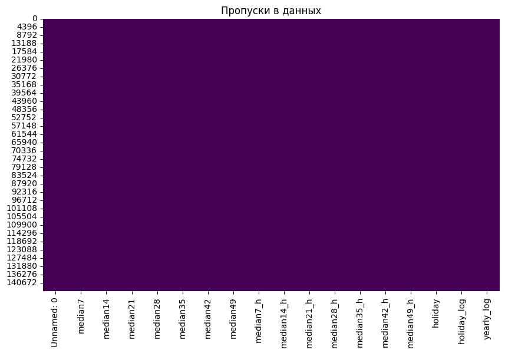

```python
import pandas as pd
import numpy as np
import matplotlib.pyplot as plt
import seaborn as sns

print("\nОбщая информация о наборе данных:")
print(df.info())

print("\nСтатистическое описание:")
print(df.describe())

print("\nПроверка на пропуски:")
print(df.isnull().sum())

plt.figure(figsize=(10, 6))
sns.heatmap(df.isnull(), cbar=False, cmap='viridis')
plt.title('Пропуски в данных')
plt.show()
```

```
Модель до удаления выбросов
```

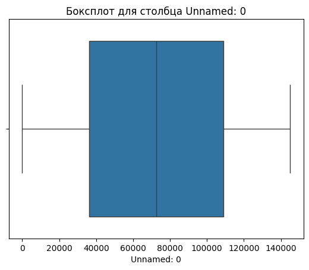

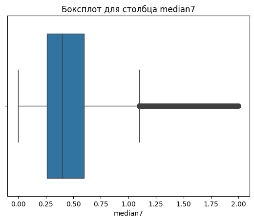

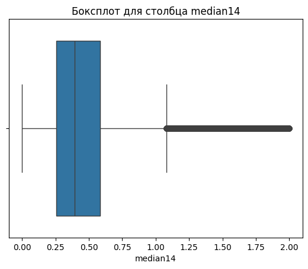

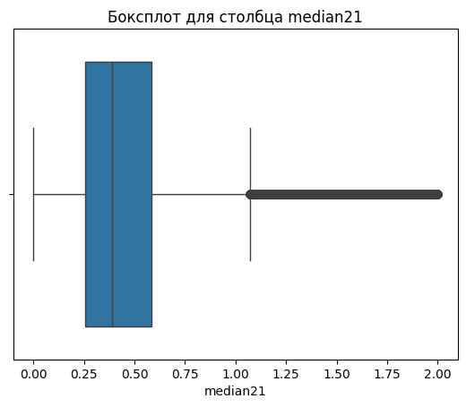

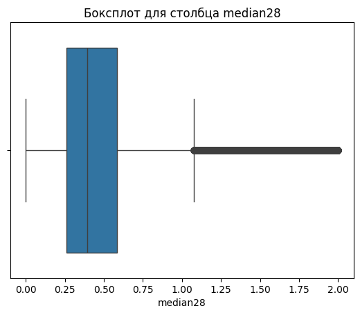

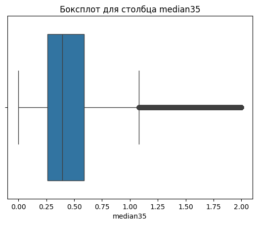

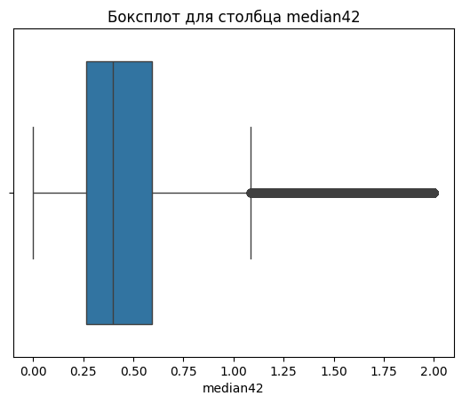

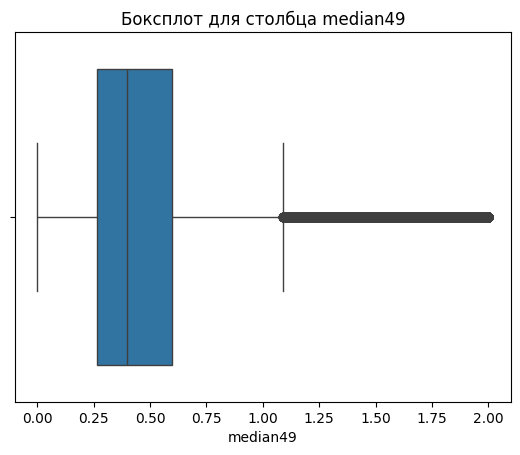

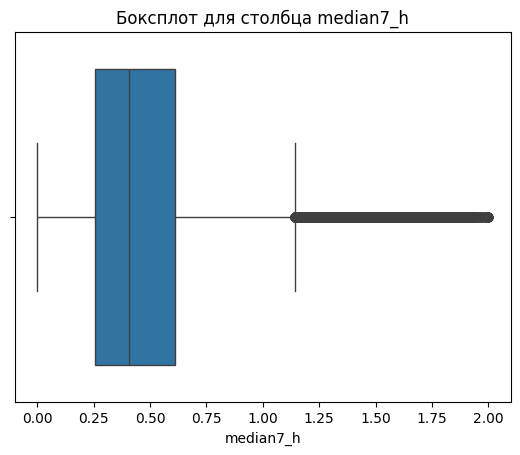

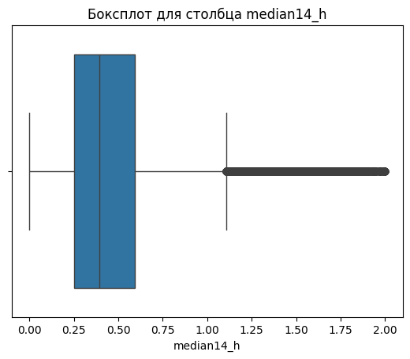

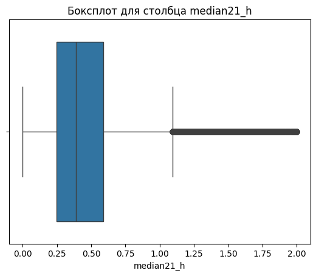

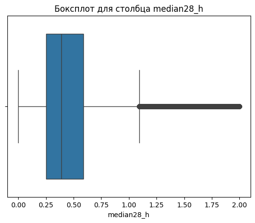

[24 more figures not shown]

```
Выбросы составили -> 22.78%
```

```python
import pandas as pd
import numpy as np
import matplotlib.pyplot as plt
import seaborn as sns

print("Модель до удаления выбросов")

start_count_row = df.shape[0]

for col in df.select_dtypes(include='number').columns:
    sns.boxplot(data=df, x=col)
    plt.title(f"Боксплот для столбца {col}")
    plt.show()

for col in df.select_dtypes(include='number').columns:
    # Настройка пороговых значений выбросов (межквартильный размах -- 1.4)
    q1 = df[col].quantile(0.25)
    q3 = df[col].quantile(0.75)
    iqr = q3 - q1

    # Фильтрация данных на основе интервала (Q1 - 1.4 * IQR) до (Q3 + 1.4 * IQR)
    df = df[(df[col] >= (q1 - 1.4 * iqr)) & (df[col] <= (q3 + 1.4 * iqr))]

df = df.dropna()

print("Модель после удаления выбросов")
print(df)

for col in df.select_dtypes(include='number').columns:
    sns.boxplot(data=df, x=col)
    plt.title(f"Боксплот для столбца {col}")
    plt.show()

final_count_row = df.shape[0]
print(f"Выбросы составили -> {((start_count_row - final_count_row) / start_count_row) * 100:.2f}%")
```

**Для решения задачи выбрать 3 модели.**

1. Модель линейной регрессии
2. Модель случайного леса
3. Модель глубокого/нейросетевого подхода

```python
import pandas as pd
import numpy as np
from sklearn.model_selection import train_test_split
from sklearn.linear_model import LinearRegression
from sklearn.tree import DecisionTreeRegressor
from sklearn.ensemble import RandomForestRegressor
from sklearn.metrics import mean_squared_error
from sklearn.metrics import mean_absolute_error, r2_score

X = df.drop(columns=['median7'])
y = df['median7']

X_train, X_test, y_train, y_test = train_test_split(X, y, test_size=0.2, random_state=42)

# 1. Линейная регрессия
linear_model = LinearRegression()
linear_model.fit(X_train, y_train)
y_pred_linear = linear_model.predict(X_test)
mse_linear = mean_squared_error(y_test, y_pred_linear)

# Вывод показателей качества моделей
print(f'MSE линейной регрессии: {mse_linear:.4f}')
print(f'R² линейной регрессии: {r2_score(y_test, y_pred_linear):.4f}')
print(f'MAE линейной регрессии: {mean_absolute_error(y_test, y_pred_linear):.4f}')
```

```
MSE линейной регрессии: 0.0019
R² линейной регрессии: 0.9418
MAE линейной регрессии: 0.0260
```

```python
# 2. Случайный лес
rf_model = RandomForestRegressor(random_state=42)
rf_model.fit(X_train, y_train)
y_pred_rf = rf_model.predict(X_test)
mse_rf = mean_squared_error(y_test, y_pred_rf)

print(f'\nMSE случайного леса: {mse_rf:.4f}')
print(f'R² случайного леса: {r2_score(y_test, y_pred_rf):.4f}')
print(f'MAE случайного леса: {mean_absolute_error(y_test, y_pred_rf):.4f}')
```

```
MSE случайного леса: 0.0019
R² случайного леса: 0.9436
MAE случайного леса: 0.0252
```

```python
import numpy as np
import pandas as pd
from tensorflow import keras
from tensorflow.keras import layers
from sklearn.model_selection import train_test_split
from sklearn.preprocessing import StandardScaler

X = df.drop('median7', axis=1).values
y = df['median7'].values

X_train, X_test, y_train, y_test = train_test_split(X, y, test_size=0.2, random_state=42)

scaler = StandardScaler()
X_train = scaler.fit_transform(X_train)
X_test = scaler.transform(X_test)

# Определение модели
model = keras.Sequential([
    layers.Dense(64, activation='relu', input_shape=(X_train.shape[1],)),  # Входной слой
    layers.Dense(64, activation='relu'),  # Скрытый слой
    layers.Dense(1)  # Выходной слой для регрессии
])

# Компиляция модели
model.compile(optimizer='adam', loss='mean_squared_error', metrics=['mae'])

history = model.fit(X_train, y_train, epochs=100, batch_size=32, validation_split=0.2)

test_loss, test_mae = model.evaluate(X_test, y_test)

predictions = model.predict(X_test)

from sklearn.metrics import mean_squared_error, r2_score, mean_absolute_error

mse = mean_squared_error(y_test, predictions)
r2 = r2_score(y_test, predictions)
mae = mean_absolute_error(y_test, predictions)

print(f"MSE: {mse}")
print(f"R²: {r2}")
print(f"MAE: {mae}")
```

```
C:\All Pro\Programs\Python\Lib\site-packages\keras\src\layers\core\dense.py:87: UserWarning: Do not pass an `input_shape`/`input_dim` argument to a layer. When using Sequential models, prefer using an `Input(shape)` object as the first layer in the model instead.
  super().__init__(activity_regularizer=activity_regularizer, **kwargs)
```

[output not shown]

[output cut: 50 more lines]

```
2241/2241 ━━━━━━━━━━━━━━━━━━━━ 4s 2ms/step - loss: 0.0015 - mae: 0.0244 - val_loss: 0.0021 - val_mae: 0.0265
2241/2241 ━━━━━━━━━━━━━━━━━━━━ 5s 2ms/step - loss: 0.0015 - mae: 0.0242 - val_loss: 0.0021 - val_mae: 0.0261
2241/2241 ━━━━━━━━━━━━━━━━━━━━ 5s 2ms/step - loss: 0.0016 - mae: 0.0245 - val_loss: 0.0022 - val_mae: 0.0275
2241/2241 ━━━━━━━━━━━━━━━━━━━━ 5s 2ms/step - loss: 0.0016 - mae: 0.0245 - val_loss: 0.0021 - val_mae: 0.0262
2241/2241 ━━━━━━━━━━━━━━━━━━━━ 5s 2ms/step - loss: 0.0015 - mae: 0.0242 - val_loss: 0.0023 - val_mae: 0.0275
2241/2241 ━━━━━━━━━━━━━━━━━━━━ 4s 2ms/step - loss: 0.0015 - mae: 0.0244 - val_loss: 0.0022 - val_mae: 0.0264
2241/2241 ━━━━━━━━━━━━━━━━━━━━ 5s 2ms/step - loss: 0.0016 - mae: 0.0245 - val_loss: 0.0021 - val_mae: 0.0261
2241/2241 ━━━━━━━━━━━━━━━━━━━━ 4s 2ms/step - loss: 0.0015 - mae: 0.0245 - val_loss: 0.0022 - val_mae: 0.0265
2241/2241 ━━━━━━━━━━━━━━━━━━━━ 4s 2ms/step - loss: 0.0015 - mae: 0.0243 - val_loss: 0.0022 - val_mae: 0.0267
2241/2241 ━━━━━━━━━━━━━━━━━━━━ 5s 2ms/step - loss: 0.0015 - mae: 0.0245 - val_loss: 0.0022 - val_mae: 0.0264
701/701 ━━━━━━━━━━━━━━━━━━━━ 1s 1ms/step - loss: 0.0020 - mae: 0.0258
701/701 ━━━━━━━━━━━━━━━━━━━━ 1s 2ms/step
MSE: 0.002040870467574371
R²: 0.9385255366051173
MAE: 0.025995666684513093
```

**Выводы:**

**Модель линейной регрессии**

1. MSE линейной регрессии: 0.0019
2. R² линейной регрессии: 0.9418
3. MAE линейной регрессии: 0.0260

**Модель случайного леса**

1. MSE случайного леса: 0.0019
2. R² случайного леса: 0.9436
3. MAE случайного леса: 0.0252

**Глубокая нейронная сеть**

1. MSE: 0.0020
2. R²: 0.9385
3. MAE: 0.02599

**Сравнительный анализ**

MSE (Среднеквадратичная ошибка): Линейная регрессия и случайный лес показали одинаковые минимальные значения MSE, что говорит о их высокой точности в предсказаниях. Глубокая нейронная сеть имеет немного более высокое значение MSE.

R² (Коэффициент детерминации): Случайный лес имеет наивысший R² (0.9436), что означает, что он лучше всего объясняет разброс данных. Линейная регрессия (0.9418) тоже демонстрирует хорошие результаты, в то время как глубокая нейронная сеть (0.9385) немного отстает.

MAE (Средняя абсолютная ошибка): Случайный лес вновь показывает лучшую производительность с наименьшим значением MAE (0.0252), что указывает на более точные предсказания. Линейная регрессия (0.0260) близка к результатам случайного леса, а глубокая нейронная сеть (0.02599) лишь немного хуже.

**Общий вывод**